# Sentiment Analysis in R

Marius Saeltzer

21 Februar 2019

Kurze Diskussion: Was erwartet ihr von diesem Kurs? Warum seid ihr hier?

TOP:

1. Wie kommen wir an Social Media Daten?
   - Einführung in R
   - Die TwitterAPI
   - Exkurs: Daten sammeln, Daten schützen
2. Wie analysiert man Social Media Daten?
   - Text als Daten
   - Textbereinigung
   - Sentiment Analysis
3. Was macht man mit Social Media Daten?
   - Anwendungsfall: Social Media und Politik
   - Ton, Follower und Anreize
   - Die Landtagswahlen in Hessen und Bayern

# Teil 1: Willkommen in Big Data

Soziale Medien sind Teil unseres Alltags geworden, wir kommunizieren in Form von privaten Kurznachrichten, aber auch in öffentlich zugänglichen Statusupdates, Kommentaren, likes und retweets. Für Sozialwissenschaftler, aber auch Unternehmen, ist das ein gewaltiger Datenschatz, der es uns erlaubt, auf direkte Befragung zu verzichten und Schlüsse aus euren digitalen Spuren zu ziehen. Dies wird besonders am Beispiel Emotionen deutlich. Für Unternehmen ist es wichtig zu wissen, ob ein Produkt gut ankommt. Für Politikwissenschaftler ist es wichtig, ob den Kommentatoren eine Rede eines Politikers gefallen hat. Doch wie lassen sich die Gefühle von tausenden Followern messen?

Ein großer Teil der ‘Big Data’ Debatte bezieht sich auf die gewaltigen Datenmengen, die soziale Netzwerke produzieren. Das Problem ist nicht mehr der Mangel, sondern der Überfluss ungeordneter Informationen. Aber wie kann man sich diese Auswertung solcher Datenmengen vorstellen? Was soll man mit 200.000 Tweets anfangen? Natürlich nicht, indem ihr sie selbst lest. Stattdessen überlassen wir es dem Computer. Dieser Workshop gibt eine Einführung in automatisierte Analyse von Sprache, sowohl theoretisch als auch praktisch. Mit der Open Source Programmiersprache R erarbeiten wir ein kleines Programm, mit dem ihr Tweets extrahieren und analysieren können. Ein besonderer Fokus liegt auf der sogenannten Sentiment Analysis, mit der wir die Wortwahl von Menschen in Texten quantifizieren können.

## Willkommen in R

R ist eine open source Programmiersprache, die in sogenannten Skripten strukturiert ist. Sie ist verwandt mit Java, Python und gehört mittlerweile zu den am häufisten verwendeten Sprachen. R ist spezialisiert auf die Analyse von Daten, eine Eigenschaft, die R von C++ und vergleichbaren ‘kompletten’ Sprachen unterscheidet.

Das Programm, das wir heute verwenden besteht aus Code Zeilen, die unterliegende Funktionen ansprechen, die ich in Unterordnern angelegt habe. Aus diesem Grund ist es wichtig, ein sogenanntes root directory, ein Wurzelverzeichnis anzulegen, und zwar an dem Ort, wo der beigefügte Ordner angelegt.

Der Zuweisungspfeil <- erzeugt sogenannte objekte. R ist eine objektorientierte Sprache. Alle neuen Objekte werden in er sogenannten Environment angelegt, die sich in RStudio rechts oben befindet.

Alles, was in Anführungszeichen steht, nennt sich Zeichenkette oder ‘string’. In R Editoren wie RStudio wird dieser leicht grünlich angezeigt. Strings eine Form von Daten, die anderen sind Wertedie ohne Anführungszeichen und blau erscheinen. Werte werden vom System direkt interpretiert, es kann sich um Zahlen handeln oder logische Operatoren.

In diesem, ersten codeblock lege ich eine reihe von Objekten an. Zuerst das Kernverzeichnies. Dieses können sie ändern. Der paste0 Befehl fügt an ihr Verzeichnis Unterpfade an. Im Prinzipt legen wir eine Karte des Verzeichnisses an.

```r
root<-'C:\\Users\\admin\\scrape'
fun<-paste0(root,'\\scripts\\functions')
script<-paste0(root,'\\scripts')
docu<-paste0(root,'\\documentation')
docufiles<-paste0(root,'\\documentation\\files')
examples<-paste0(root,'\\examples')
dat<-paste0(root,'\\data')
```

## Installation von Paketen

Wir haben nun eine Reihe von Objekten angelegt. Objekte, einmal mit dem Pfeil definiert, können einfach angesprochen werden. Wenn wir also root ausführen, erscheint der Inhalt.

```r
root
```

```
## [1] "C:\\Users\\admin\\scrape"
```

Wir nutzen ein Adressobjekt, um das Arbeitsverzeichnis zu ändern. Dort befindet sich unser erstes Skript: unpack.R.

Der Befehl zum ändern des Arbeitsverzeichnis ist setwd(). Mit dem source Befehl führen wir das dort liegende erste Skript aus, welches sogenannte Pakete installiert.

R ist eine open source Programmiersprache die kontinuierlich erweitert und verbessert wird. Wer R eine neue Funktion geben möchte, tut dies in Form installierbarer Erweiterungen, sogenannter Packages.

```r
setwd(fun)
#source('unpack.R')
```

Nach der Installation müssen wir die Pakete noch aktivieren. Das wichtigste ist rtweet, welches uns Zugriff auf die Twitter Daten erlaubt.

```r
library(rtweet)
library(stringr)
library(ggplot2)
library(dplyr)
library(qdapRegex)
library(wordcloud)
library(utils)
```

Wir beginnen mit der Datensammung. Zu diesem Zweck brauchen wir einen twitter API key. Diesen erhalten wir, sobald wir einen Twitter Entwickler Zugang haben. Twitter genehmenigt für Mitglieder von Bildungseinrichtungen, aber auch kommerziellen Enticklern Zugänge ohne größere Nachweispflicht. Für eigene Analysen empfehle ich, einen Account zu beantragen. Für diesen Workshop stelle ich meine Keys bereit. Sie befinden sich unter einem temprorären Dropboxlink

```r
toklink<-''
```

## Datensammlung

call_api ist ein für diesen Kurs angepasste und vereinfachte Form der twitterAPI. Sie erlaubt das aufrufen beliebiger Accounts. Input ist ein sogenannter Vektor. Die Call API macht aus diesem vektor eine Anfrage und speichert alle Ergebnisse in einen data ordner den wir für unsere Datenverarbeitung nutzen. Sie können einige accounts eintragen, immer getrennt durch Kommata und in Anführungszeichen. Ersetzen sie ‘spdbt’, den Account der SPD Bundestagsfraktion durch einen Account ihrer Wahl.

```r
setwd(script)
source('0_Call.R')
input<-c('spdbt')
call_api(input,toklink=toklink)
```

### Daten einlesen

Jetzt sollten sich einige csv files in dem data Ordner befinden. Die nächste Funktion läd diese nun in die Environment

```r
setwd(script)
source('1_select.R')
## here we should specify
working<-import_tw(dat) #inp=input if your want a specific account, not all
```

### Daten inspizieren

Herzlichen Glückwunsch, Sie haben ihre ersten Social Media Daten gesammelt. Das Objekt working beinhaltet jetzt unsere Tweets. Sie können oben rechts auf den kleinen blauen Pfeil vor working klicken und lesen, was Sie so gefunden haben. Die maximale Anzahl pro account ist auf die letzten 3200 tweets limitiert, eine Vorgabe von Twitter. Schauen wir mal, was wir alles gefunden haben.

### Datenreichtum auf Twitter

Twitter bietet die Möglichkeit eine Vielfalt an Daten zu bekommen, die wir nutzen können um uns ein Bild über die Nutzer zu machen und ihre Verhaltensweisen zu studieren.

Zunächst schauen wir uns einmal die Vielfalt an Variablen an:

```r
names(working)
```

```
##  [1] "X"                       "user_id"
##  [3] "status_id"               "created_at"
##  [5] "screen_name"             "text"
##  [7] "source"                  "display_text_width"
##  [9] "reply_to_status_id"      "reply_to_user_id"
## [11] "reply_to_screen_name"    "is_quote"
## [13] "is_retweet"              "favorite_count"
## [15] "retweet_count"           "ext_media_type"
## [17] "lang"                    "quoted_status_id"
## [19] "quoted_text"             "quoted_created_at"
## [21] "quoted_source"           "quoted_favorite_count"
## [23] "quoted_retweet_count"    "quoted_user_id"
## [25] "quoted_screen_name"      "quoted_name"
## [27] "quoted_followers_count"  "quoted_friends_count"
## [29] "quoted_statuses_count"   "quoted_location"
```

[output cut: 21 more lines]

Der names() Befehl sagt uns, was wir über jeden Tweet wissen. Hierbei handelt es sich um die Variablennamen unseres Datensatzes. Was denken Sie, was wir nun über die Tweets herausfinden können? Besprechen Sie sich kurz mit den anderen Seminarteilnehmern und überlegen, was wir alles üben den Account herausgefunden haben.

Unser Datensatz enthält nur Informationen über die tweets eines einzigen Accounts. Daher gibt es viele Variablen, die komplett gleich bleiben. Für eine bessere Übersicht, reduzieren wir Variablenanzahl um mehr über die einzelnen Tweets zu erfahren.

```r
setwd(fun)
source('tweetvariation.R')
working<-tweetvariation(working)
```

Zunächst können wir schauen zu welchen Uhrzeiten mit welchem Gerät die Person deren Acccount wir gesrcaped haben twittert:

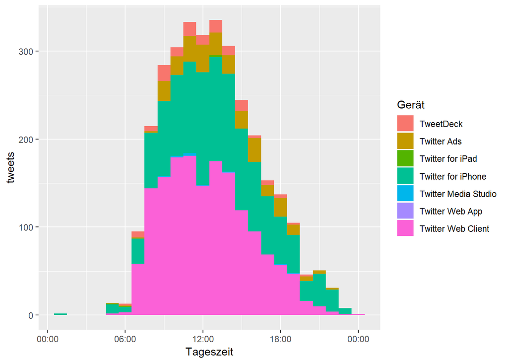

```r
daytime<-ggplot(working, aes(x=as.POSIXct(hour, format="%H:%M:%S"),fill=source))
daytime +scale_x_datetime(labels = function(x) format(x, format = "%H:%M"))+
        labs(x="Tageszeit", y="tweets", fill="Gerät")+
        geom_histogram(binwidth = 3600)
```

Diskussion: Was sind die Datenschutz Implikationen dieser Daten?

# Teil 2: Was tun mit Big Data?

Wieviele tweets haben Sie gefunden? Hätten Sie Lust, diese alle zu lesen?

```r
print(working$text[sample(10)])
```

```
##  [1] "Mit der Brückenteilzeit, dem sozialen Arbeitsmarkt und dem Starke-Familien-Gesetz haben wir wichtige Schritt im Kampf gegen Armut umgesetzt, sagt @A_Gloeckner im #Bundestag. Mit #Bürgergeld, #Grundrente und einem modernen #Sozialstaat2025 soll es weiter gehen. https://t.co/DxXksyMZ2M"
##  [2] "Die #FDP will Beschäftigte im #Tourismus länger arbeiten lassen. @GabiHillerOhm verweist auf die gesundheitlichen Auswirkungen. \"Deshalb machen wir bei diesen Plänen nicht mit.\" Wir wollen einen Tourismus mit guter Arbeit und Nachhaltigkeit: https://t.co/ykm4SzGlXZ https://t.co/xzRmPpAs73…
##  [3] "Der KoaV regelt klar: Wir brauchen eine #NationaleTourismusstrategie! Vom Beauftragten für #Tourismus der BuReg kam bisher fast nix. Die @spdbt legt mit umfassenden Positionspapier schon mal vor. Herr Bareiß, bedienen Sie sich! \n\n#Wassertourismus #Reisen #Erholung #SPD #SPDwirkt https://t…
##  [4] "In der heutigen Debatte um das Rahmenprogramm Gesundheitsforschung habe ich die Gelegenheit genutzt, um auf den Fall von Astrid aufmerksam zu machen. Sie ist 41 Jahre alt und sucht einen Stammzellenspender. Helfen wir ihr! #matchmymix https://t.co/ZSafvInQb7"
##  [5] "Geld für Seemannsheime verdoppelt! Gut angelegt im doppelten Sinne für die wichtige Arbeit in den Häfen! https://t.co/sjnPR7c8XR"
##  [6] "Die SPD sagt der Armut den Kampf an! @matthiasbartke erklärt im #Bundestag, warum wir dabei auf ein \"Recht auf Arbeit\" setzen, statt auf ein bedingungsloses #Grundeinkommen. #BGE https://t.co/Fp61fMQybF"
##  [7] "Wir wollen eine #Grundrente ohne Bedürftigkeitsprüfung. Es geht um Menschen, die über Jahrzehnte durch ihre Arbeit die Gesellschaft zusammengehalten haben, sagt @matthiasbartke. Diese Menschen sollen nicht zum Amt gehen müssen, um staatliche Hilfe zu beantragen. #Bundestag https://t.co/9wHu…
##  [8] "Frauen sind von Kriegen besonders betroffen. Gleichzeitig sind Friedensverträge mit weiblicher Beteiligung stabiler. @mi_muentefering kündigt deshalb an, dass Deutschland im UN-Sicherheitsrat einen Schwerpunkt auf das Thema \"Frauen, Frieden, Sicherheit\" legen wird. https://t.co/FpizbYqOn2…
##  [9] "Gesundheitsminister Spahn will sein Ministerium grundsätzlich ermächtigen, allein zu entscheiden, welche neuen Behandlungsmethoden von den Krankenkassen übernommen werden. Unsere gesundheitspolitische Sprecherin @dittmarsabine lehnt das ab. https://t.co/6aTanhV1TB"
## [10] "Ein großer Teil der Gesundheitsforschung widmet sich der Frage, wie sich Krankheiten verhindern lassen. René Röspel begrüßt, dass mit dem Rahmenprogramm Gesundheitsforschung auch soziale Bedingungen untersucht werden. #Bundestag https://t.co/0jYTHyb2ep"
```

Bei 3200 Tweets ist das sicher noch machbar, aber wie sieht es mit den Tweets aller Abgeordneten des Deutschen Bundestages ( ca 300.000 Tweets)?

Um diese Daten analysieren zu können, müssen wir über das manuelle Bearbeiten von Textdaten hinausgehen. Die Herausforderung ist weniger das Sammeln der Daten, als das sinnvolle Interpretieren.

## Text als Daten

Sprache ist eine sehr menschliche Konstruktion: sie ist mehrdeutig, konventionsgebunden, sozial konstruiert und komplex. Um mit Computern, die auf reiner Logik basieren, zu kommunizieren wurden Programmiersprachen entworfen, die eben nicht (oder nur begrenzt), menschlichen Angewohnheiten unterworfen sind. Dem gegenüber steht die ‘Natürliche Sprache’, dem Namensgeber des Natural Language Processing (NLP).

Für Computer kann menschliche Grammatik unnötig komplex sein. Die Leistung, die ein menschliches Gehirn erbringt beim konstruieren und flektieren von Sätzen ist äußerst rechenintensiv. Aus diesem Grund verwenden einfache Suchalgorithmen den sogenannten ‘Bag of Words’ Ansatz: wir betrachten Texte als ungeordnete Ansammlungen mehr oder weniger bedeutungsvoller Worte. Satzbau und Flektionen werden ignoriert. Dem Gegenüber steht der Word-in-Context Ansatz, der deutlich höher entwickelt ist aber für die Aufgaben, die wir hier haben nicht wirklich besser funktioniert.

Um eine Brücke zu schlagen zwischen natürlicher Sprache und den Daten, die ein Computer interpretieren kann brauchen wir zwei Stufen von Sinnreduktion. Erst eine formale, dann eine inhaltliche. Der erste Schritt ist die Bereinigung von Texten, dem sog. Text-Preprocessing

### Bereinigung

Menschliche Sprache besteht aus viel Kram, den Computer nicht brauchen. Wenn wir Texte als ‘Wortsäcke’ betrachten, brauchen wir keine Zahlen, Interpunktion, Bindeworte und Flektionen. Letzteres ist für die deutsche Sprache etwas umstritten, daher habe ich die Option eingebaut, Flektionen zu erhalten.

Soziale Medien insesondere bestehen aus vielen Dingen, die schwer zu interpretieren sind: URLs, hashtags, mentions, emoticons. Diese Dinge würden in einer Analyse beim Vergleich mit natürlicher Sprache eigenartige Effekte haben. Daher werden diese auch entfernt.

```r
setwd(script)

source('2_Preprocessing.R')

working$clean<-cleaner(working)
```

Ein Beispiel: Was passiert mit einem beliebigen Tweet?

```r
i<-17
print(cbind(working$text[i],working$clean[i]))
```

```
##      [,1]
## [1,] "Die Regierungsbefragung wird verlängert, dreimal im Jahr muss sich die Kanzlerin befragen lassen: Die Fragestunde aufzuwerten und dem #Bundestag mehr Rechte zu geben, war der @spdbt so wichtig, dass wir das zu einer Bedingung dieser Koalition gemacht haben, sagt @schneidercar. https://t.co/…
##      [,2]
## [1,] " regierungsbefragung  verlängert dreimal  jahr    kanzlerin    fragestunde aufzuwerten    rechte            bedingung  koalition    "
```

### Was Leute so schreiben

Nun, nachdem wir die irrelevanten Worte und Zeichen entfernt haben, verschaffen wir uns einen Überblick wie der Wortsack aussieht.

In den meisten text-as-data Ansätzen werden die Worthäufigkeiten in einem Text genutzt um Aussagen über einen Text zu treffen. Um einen Überblick über die genutzten Wörter unseres Twitterers zu bekommen, können wir eine Wordcloud verwenden.

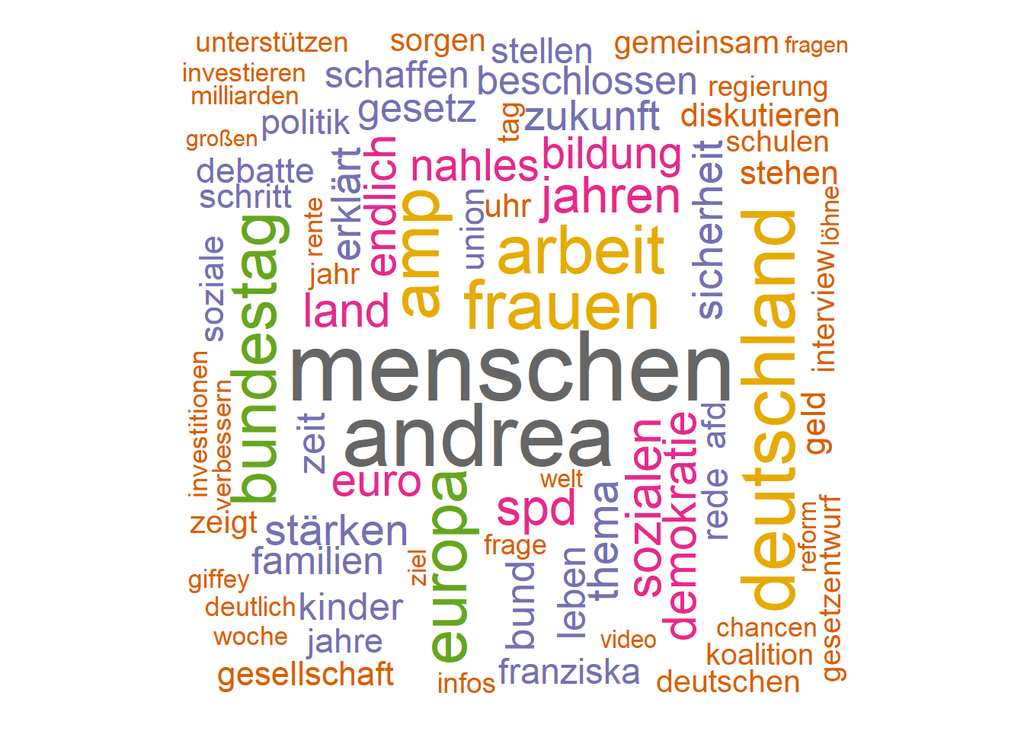

```r
setwd(fun)
source('wfm.R')

d<-wfm(working)
set.seed(1234)
wordcloud(words = d$word, freq = d$freq, min.freq = 1,
          max.words=100, random.order=F, rot.per=0.35,
          colors=brewer.pal(8, "Dark2"))
```

Hier haben wir die 3200 Tweets bereits stark reduziert, so dass wir mit einem Blick einen Eindruck bekommen.

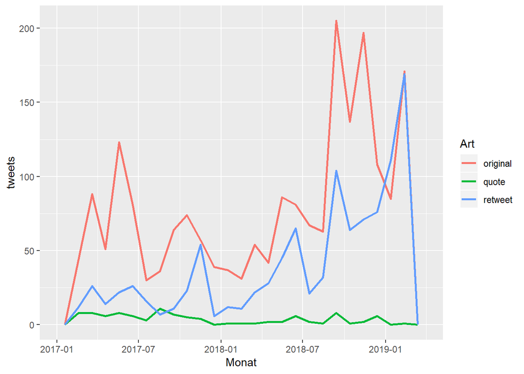

```r
timetrend<-ggplot(working, aes(x=day, col=type))
timetrend+geom_freqpoly(binwidth=2604800, size=1)+
  labs(x="Monat", y="tweets", col="Art")
```

```r
# binwidth: woche-> 604800, tag-> 86400, monat -> 2.6 mio
```

Für den ersten Blick ist das erhalten von Flektionen angenehm, für die Analyse hingegen kann es sinnvoll sein, Wortähnlichkeiten zu erhöhen und Variation zu reduzieren.

```r
working$clean<-cleaner(working,stem=T)
```

Aus diesem Grund reduzieren wir alle Worte auf ihren Wortstamm.

```r
i<-17
print(cbind(working$text[i],working$clean[i]))
```

```
##      [,1]
## [1,] "Die Regierungsbefragung wird verlängert, dreimal im Jahr muss sich die Kanzlerin befragen lassen: Die Fragestunde aufzuwerten und dem #Bundestag mehr Rechte zu geben, war der @spdbt so wichtig, dass wir das zu einer Bedingung dieser Koalition gemacht haben, sagt @schneidercar. https://t.co/…
##      [,2]
## [1,] "regierungsbefrag verlangert dreimal jahr kanzlerin fragestund aufzuwert recht beding koalition"
```

Das sieht erstmal nach Kauderwelsch aus. Dennoch ist die Performanz dieser Ansätze deutlich höher.

## Sentiment Analyse

Doch was bedeuten diese Worte? Wir können uns mit der Wordcloud einen Eindruck verschaffen und beschreiben, worüber der Account twittert. Aber die Interpretation ist sehr subjektiv. Wie vergleichen wir die Bedeutung von Worten? Wie würden wir diesen Account mit einem anderen vergleichen? Wie können wir ihn analysieren?

Es gibt eine Reihe von Dimensionen von Sprache. Wie kompliziert ist ein Text? Ist er politisch links? Ist er Spam? Skalierungsverfahren erlauben anhand von relativen Worthäufigkeiten zu differenzieren.

In diesem Workshop geht es um Emotionalität, eine weitere Dimension, die man basierend auf Wortverwendung erfassen kann. Wie emotional sind die Worte, die ein Account verwendet? Sind sie positiv oder negativ?

Sentiment oder Tonanalyse stammt ursprünlich aus der Marktforschung, dem Opinion Mining. Wie kann man automatisiert erkennen, ob tausende von Kunden ein Produkt mögen oder nicht. Die sogenannte Sentiment Analyse gibt uns Aufschluss. Für diesen Zweck nutzen wir vordefinierte Dictionaries. Dictionaries sind Wörterbücher die zwischen dem Computer und der natürlichen Sprache vermitteln. Die übersetzen Worte in Zahlen, in einen Tonalitätsangae auf einer einigen Dimension. Diese Dimension bezieht sich auf Positivität und Negativität. Basierend darauf, ob die Worte vorkommen oder nicht wird den Texten eine Score zugewiesen.

```r
setwd(script)
source('3_Dictionary.R')
dict<-get_senti()
print(dict[sample(nrow(dict),10),])
```

```
##           X          word  values
## 26712 11080   rosaroteres  0.0040
## 1229   1229        Streit -0.6632
## 8632   8632   monotonerem -0.0533
## 5854   5854  gefährlichen -0.6366
## 1854   1854  abschrecktet -0.1780
## 30500 14868 wohlgeordnete  0.0040
## 22348  6716      gnädigem  0.0040
## 9715   9715  schaurigeren -0.0048
## 28169 12537       topptet  0.0040
## 9770   9770   schlappstem -0.0048
```

### Dictionary Analysis

Wir verwenden hier zwei deutschsprachige Dictionaries

Den klassichen SentiWS für die deutsche Allgemeinsprache

*Remus, Robert; Quasthoff, Uwe; Heyer, Gerhart (2010): SentiWS - a Publicly Available German-language Resource for Sentiment Analysis. In: Proceedings of the 7th International Language Ressources and Evaluation, pp. 1168-1171.*

Einen sehr neuen, auf Politik zugeschnittenen SentiCorpus

*Christian Rauh (2018) Validating a sentiment dictionary for German political language-a workbench note, Journal of Information Technology & Politics, 15:4, 319-343, DOI: 10.1080/19331681.2018.1485608*

```r
res_senti<-apply_senti(working,'sentiws',stemmed=T)

rau_senti<-apply_senti(working,'rauh',stemmed=T)
```

```r
rauhscore<-rau_senti$score
rauhpol<-rau_senti$pol
res<-cbind(res_senti,rauhscore,rauhpol)
```

Wir fügen ein paar unserer gewonnenen Daten in einen einzigen Datensatz zusammen und beginnen mit der Analyse der Sentiments

### Überblick über sentiment Analyse

Um einen ersten Überblick für unsere Sentiments zu bekommen, können wir untersuchen wie unser Nutzer in der letzten Woche getweetet hat.

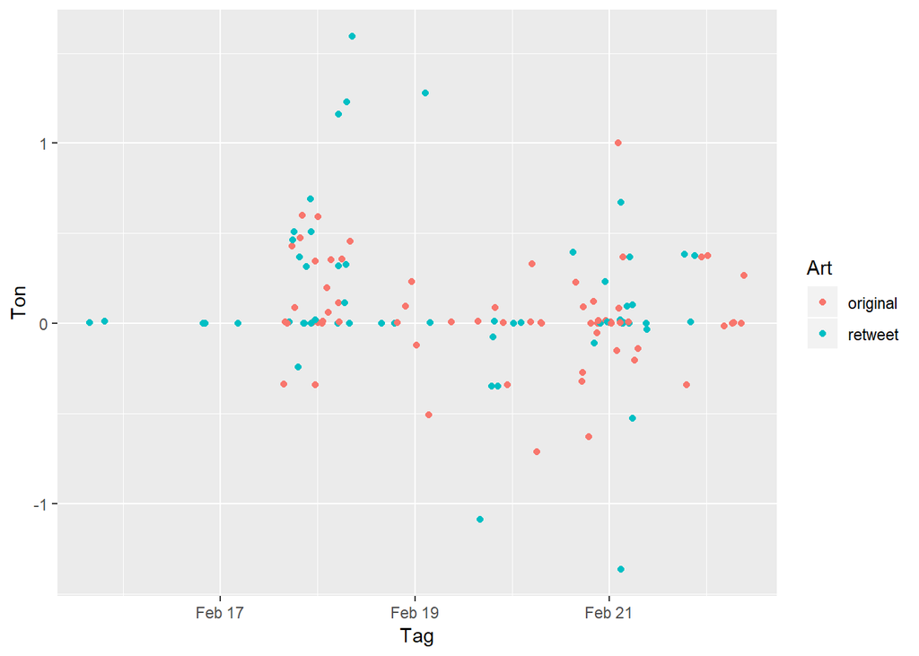

```r
lastweek<- ggplot(res[res$day>"2019-02-15",], aes(x=day, y=score, col=type))
lastweek+geom_jitter()+
  labs(x="Tag", y="Ton", col="Art")
```

### Validierung

Natürlich sind dictionary approaches mit Problemen behaftet, die gilt im Besondern für deutsche social media Daten. Informelle Sprache macht es dem Computer schwer, die Wörter aus den Dictionaries zuzuordnen. Daher unterschätzen Dictionaries die Negativität. Weiterhin gibt es Probleme mit Verneinung und Sarkassmus. Wir können diese Probleme durch Handcoding validieren.

Übung: Laden Sie eine csv file herunter und codieren Sie die tweets entspechend der Instruktionen im Ordner .

```r
setwd(root)
write.csv(working[1:30,4],'validate.csv')
```

Moderne Ansätze an Sentiment Analysis verwenden daher Supervised Machine Learning. Anstatt selbst zu definieren, welche Worte positiv oder negativ sind, codieren wir tweets in toto und lassen den Computer semantische Muster extrahieren. Dies ist eine Vorstufe der künstlichen Intelligenz und geht über die Reichweite dieses Seminars hinaus.

Diskussion: Ergibt es Sinn, Stimmungen durch solche Instrumente zu messen?

# Teil 3: Ton und Politik in den Sozialen Medien

Wie hängen Emotionen in den Sozialen Medien mit Politik zusammen? Spätestens seit der Trump Präsidentschaft spielt Twitter eine große Rolle in der Art und Weise, wie wir Politik wahrnehmen. Diskussion um Filterblasen, die Verrohung des Tons, Trolle, Shitstorms und Bots sind an der Tagesordnung. Diesen Problemen auch empirisch auf den Grund zu gehen ist eine der Aufgaben der Politikwissenschaft.

Wir stellen uns die Frage, ob die Sozialen Medien Politiker verändern, ob sich diese möglicherweise anpassen und ihren Ton verschärfen, wenn sie dafür belohnt werden mit likes und retweets.

*Twitter ist, wie kein anderes digitales Medium so aggressiv und in keinem anderen Medium gibt es so viel Hass, Böswilligkeit und Hetze. Offenbar triggert Twitter in mir etwas an: aggressiver, lauter, polemischer und zugespitzter zu sein - und das alles in einer Schnelligkeit, die es schwer macht, dem Nachdenken Raum zu lassen. Offenbar bin ich nicht immun dagegen.* **Robert Habeck**

Wir fragen uns also: Setzt Twitter Anreize negativ zu tweeten? Und wenn ja, warum ist das so? Liegt es an der Filterblase?

## Negativität und Retweets

Jetzt können wir schauen, ob ein bestimmter Ton unterschiedliche Reaktionen bei den Followern auslöst:

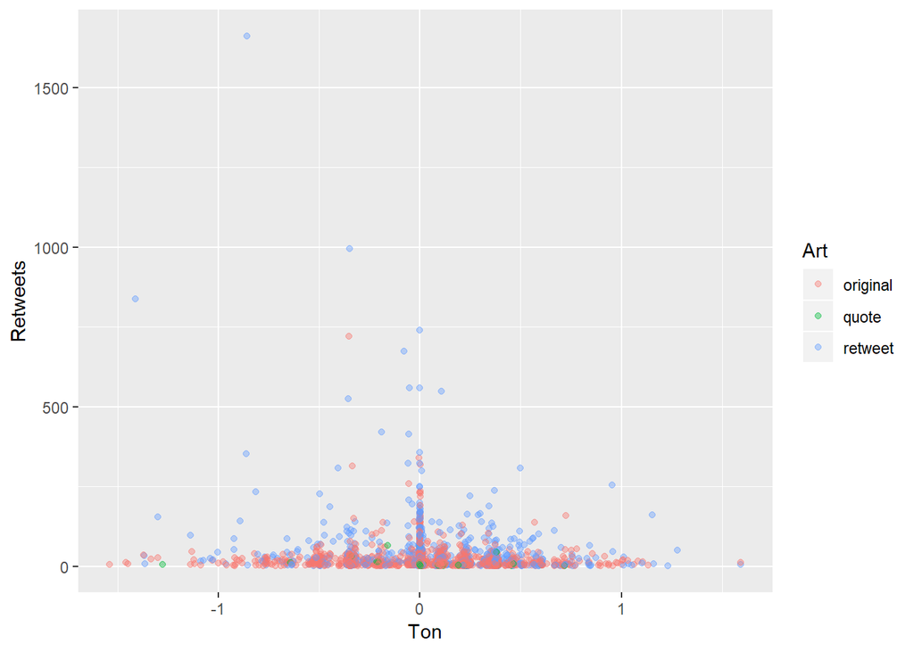

```r
reaction<- ggplot(res[res$retweet_count>0,], aes(x=score, y=retweet_count, col=type))
reaction+geom_point(alpha=0.4)+
  labs(x="Ton", y="Retweets", col="Art")
```

Dieser Plot verrät uns noch nicht all zu viel über unseren Twitterer. Daher sollten wir weiterführende Statistiken benutzen.

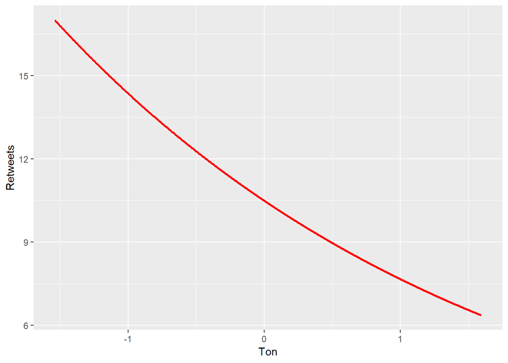

```r
library(MASS)
m<-glm.nb(retweet_count~score+hashtag_count+URL_dummy, data=res[res$is_retweet==F,])

setwd(fun)
source('predictdata.R')
pred_score<-predict.by.score(model=m, data=res[res$is_retweet==F,])

t.effect<- ggplot(pred_score, aes(x=score, y=pred))
t.effect+geom_line(size=1, col="red")+
  labs(x="Ton", y="Retweets")
```

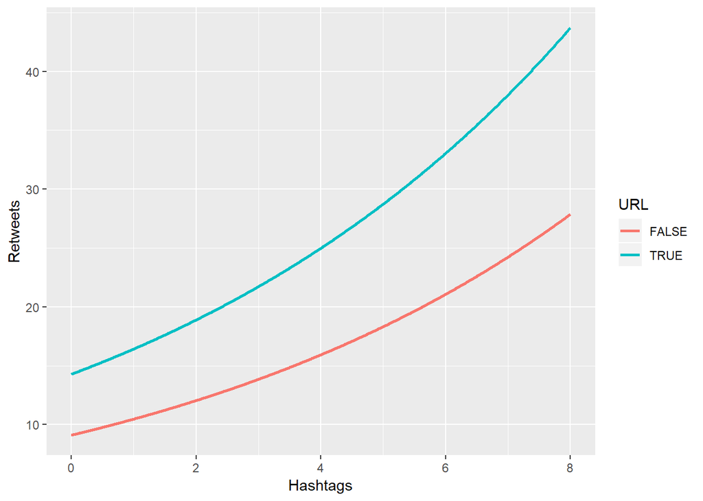

```r
pred_prof<-predict.by.prof(model=m, data=res[res$is_retweet==F,])

prof.effect<- ggplot(pred_prof, aes(x=hashtag_count, y=pred, col=URL_dummy))
prof.effect+geom_line(size=1)+
  labs(x="Hashtags", y="Retweets", col="URL")
```

## Forschungsergebnisse

Nachdem wir jetzt untersucht haben, wie auf verschiedene Tweets eines einzelnen Nutzers reagiert wird, zeigen wir jetzt Ergebnisse unserer eigenen Forschung.

Zu diesem Zweck haben wir hier einen Datensatz aller Kandidaten der Landtagswahlen in Hessen und Baynern, die einen Twitter Account haben.

```r
setwd(examples)
tweet.data<- read.csv("tweet_data.csv")
```

Dieser Datensatz wurde mit den selben Instrumenten erzeugt und bearbeitet, die wir eben kennengelernt haben. Die Mehrebenenstruktur der Daten und die Eigenschaften der abhängigen Variable machen eine kompliziertere Analyse notwendig.

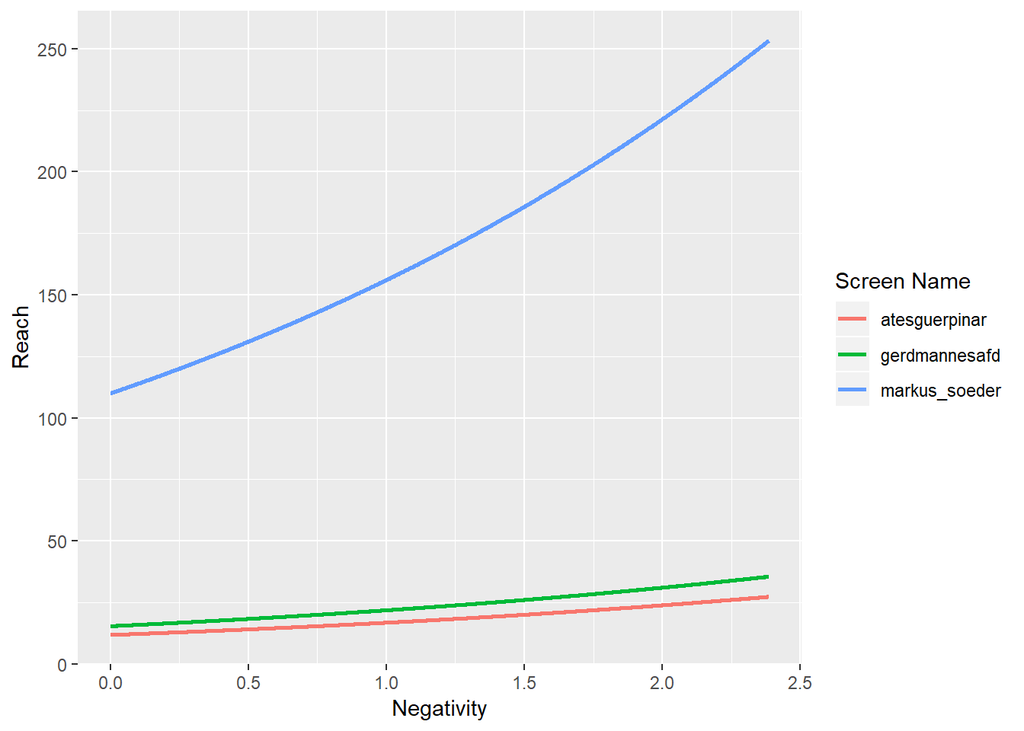

```r
library(lme4)

Plot.model<- glmer.nb(reach~neg+hashtag_count+URL_dummy+
                     (1|screen)+(1|party),
                   data=tweet.data, nAGQ=0)

setwd(fun)
source('predictdata.R')
candidate.prediction<- predict.full(Plot.model, tweet.data,
                                    c("gerdmannesafd", "markus_soeder", "atesguerpinar"),
                                    c("AfD", "Union", "DIE LINKE"))
pred.curve<- ggplot(candidate.prediction, aes(x=neg, y=pred, col=screen))
pred.curve+geom_line(size=1)+
  labs(x="Negativity", y="Reach", col="Screen Name")
```

## Anreize und Echokammern

Wir sind noch einen Schritt weiter gegangen und haben nicht nur geschaut, ob es allgemein für Politiker einen Negativity incentive gibt, wie stark dieser für verschiedene Politker is und ob er sich durch die Struktur der Follower erklären lässt. In anderen Worten: Sorgen Echokammern dafür, dass Politiker eher bereit sind zu polarisieren?

Um dies zu messen, haben wir die ideologischen Positionen der Follower geschätzt. Diese Methodik selbst auszuprobieren sprengt den Rahmen des Workshop da die Rechenzeit dies mit 16.000 Followern, auf denen der Datensatz basiert, zu berechnen in etwa der Länge des Workshops entspricht.

Kurz gesagt betrachten wir die soziale Netzwerkposition in Form von Friends, wem also gefollowed wird. Wir gehen davon aus, das Menschen homophil sind. Das bedeutet Sie bauen soziale Beziehungen eher mit Menschen auf die ihnen ähnlich sind, als unähnlich. Menschen die den gleichen Accounts folgen sind sich also ähnlich. Nur was ist die Dimension der Ähnlichkeit? Für diesen Zweck haben wir die Friends aus einer politisch geprägten Stichprobe gesammelt. Wir gehen davon aus, dass die Entscheidung einem Politiker zu folgen vor allem durch die politische Einstellung geprägt ist.

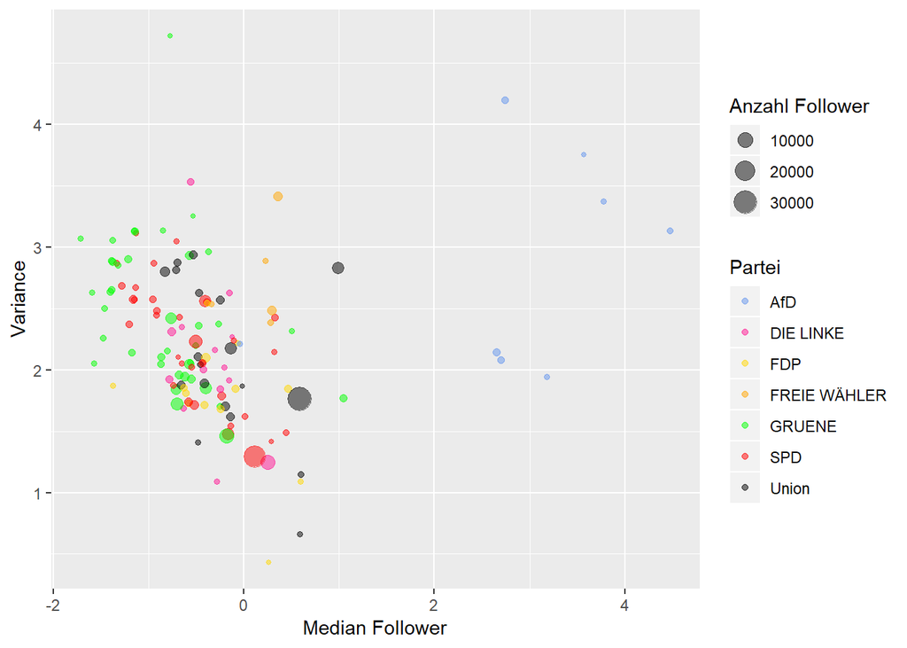

```r
setwd(examples)
individual.data<- read.csv("secondary_data.csv")
individual.data<- individual.data[complete.cases(individual.data),]
my.colors<- c("cornflowerblue","deeppink","gold", "orange","green","red", "black")
aud.str<-ggplot(individual.data, aes(x=median_pos, y=var_pos, col=party, size=followers_count))
aud.str+geom_point(alpha=0.5)+
  labs(x="Median Follower", y="Variance", col="Partei", size="Anzahl Follower")+  scale_color_manual(values = my.colors)
```

Was wir nun hier sehen ist eine Grafik des ideologischen Spektrums der Landtagswahlen. Jeder Kreis ist ein Politiker und die Position in dem Raster stellt seine Followerschaft dar. Je weiter links in der Grafik, umso weiter Links ist der durchschnittliche Follower. Je weiter oben in der Grafik, umso höher ist die Varianz, also die Weite der Followerschaft. Politiker die hier eine hohe Varianz haben werden von sehr **unterschiedlichen* Menschen gefolgt.

Was fällt ihnen an dem Graphen auf?

### Was erklärt den Anreiz negativ zu sein?

Wir verwenden nun diese Verteilung um die Stärke des Negativitätsanreizes pro Politiker zu schätzen. Wir vermuten, dass je homogener die Follower, umso größer der Anreiz, denn wenn man eine Filterbubble hat, wollen alle in etwa das gleiche hören.

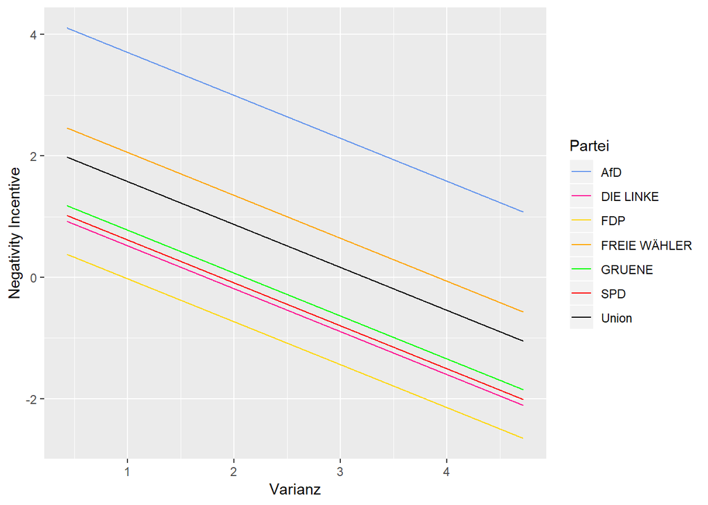

```r
neg.model<- lm(neg.x~var_pos+median_pos+log(followers_count)+party-1, data=individual.data)

setwd(fun)
source('predictdata.R')
my.colors<- c("cornflowerblue","deeppink","gold", "orange","green","red", "black")

effect.var<- predict.secondary(neg.model, individual.data, by.var = T)
var.effect<- ggplot(effect.var, aes(x=var_pos, y=pred, col=party))
var.effect+geom_line()+
  labs(x="Varianz", y="Negativity Incentive", col="Partei")+  scale_color_manual(values = my.colors)
```

In diesem Plot sieht man, dass unsere Theorie nicht ganz falsch ist. Wir sehen nich nur, dass die zunehmende Varianz die Retweet rate pro negativem Tweet reduziert, sondern auch das die Parteimitgliedschaft einen Anreiz schafft.

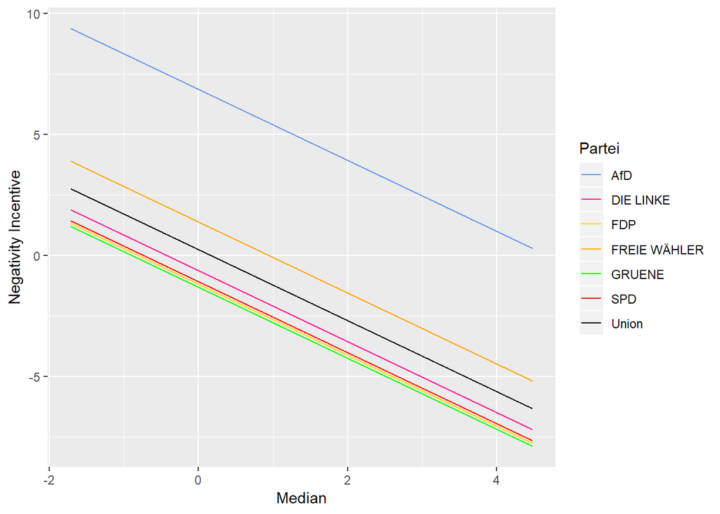

```r
effect.med<- predict.secondary(neg.model, individual.data, by.var = F)
my.colors<- c("cornflowerblue","deeppink","gold", "orange","green","red", "black")
med.effect<- ggplot(effect.med, aes(x=median_pos, y=pred, col=party))
med.effect+geom_line()+
  labs(x="Median", y="Negativity Incentive", col="Partei")+  scale_color_manual(values = my.colors)
```

Eine Erklärung kann hier sein, dass Parteien die so oder so negativ sind, keinen weiteren Nutzen aus zusätzlicher Negativität ziehen. Für Parteien, die meistens positiv sind, ist es eher etwas besonderes.

### Abschlussdiskussion: Asoziale Medien?